# Population pyramids using ‘express’ ggplot2 extension strategies

Gina Reynolds

2024-08-12

## Intro Thoughts

New Stat functionality can help ggplot2 become more expressive and more of a joy to use. However, guidance for creating new layers has typically involved a fair amount of ‘scaffolding’ code, which can be hard to manage and can make scripts less readable.

This exercise explores some *new strategies* for using new Stat definitions.

We show two ‘express’ extension strategies, one that requires no dependencies and another that uses the `statexpress` package to define user-facing functions. Both aim at allowing authors to skip the ‘scaffolding/boiler plate’ code, and focus their attention on the compute they wish to use to get from input data to render-ready.

We start with ‘base’ ggplot2 build, and turn to on-the-fly extension.

## Step 0. Status Quo, no use of extension mechanisms (ggproto)

Inspiration, and data, for this exercise comes from… https://rfortherestofus.com/2024/07/population-pyramid-part-1

We build the plot in single panel (no patchwork) as used in the blog post. We’ll use the computation lessons in the compute in the extensions in the next section.

```r
library(tidyverse)


oregon_population_pyramid_data <-
  read_csv("https://raw.githubusercontent.com/rfortherestofus/blog/main/population-pyramid-part-1/oregon_population_pyramid_data.csv")
```

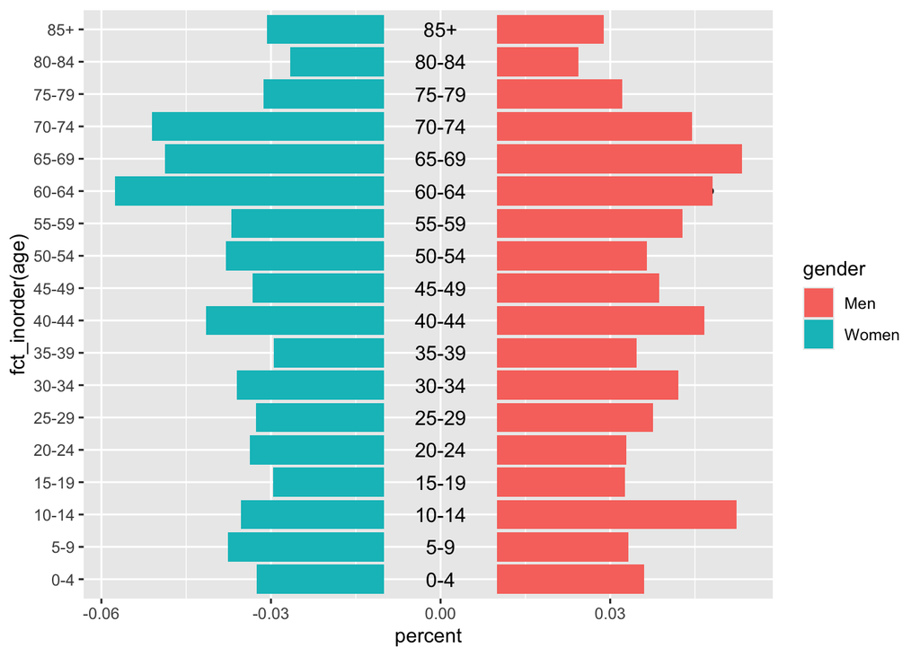

```r
sep = 0
sep = .01

# we will use GeomRect for it's flexibility instead of Col or Bar
oregon_population_pyramid_data %>%
  filter(county == "Baker") %>%
  # move 'zero' out from center
  mutate(zero_shift = ifelse(gender == "Men", sep, -sep)) %>%
  mutate(xmin = 0 + zero_shift) %>%
  # max needs to be flipped, and shifted
  mutate(xmax = percent * ifelse(gender == "Men", 1, -1) + zero_shift) %>%
  mutate(y = as.numeric(fct_inorder(age))) %>%
  # we need to compute ymax and min because we are using GeomRect
  mutate(ymax = y + .45 * 1) %>%
  mutate(ymin = y - .45 * 1) %>%
  ggplot() +
  aes(y = fct_inorder(age), x = percent) +
  geom_point() +
  geom_rect(aes(xmin = xmin, xmax = xmax,
                ymin = ymin, ymax = ymax)) +
  aes(fill = gender) +
  aes(label = age) +
  geom_text(aes(x = 0, fill = NULL), data = . %>% distinct(age))
```

# Option 1. dependency-free, light-weight layer definition

Use ggproto to define new Stat, then use that directly with a user-facing geom_*() function, replacing the Stat argument.

## Create new Stat (upper-case)

```r
compute_panel_pyramid <- function(data, scales, sep = 0, neg_cat = NULL){

  if(is.null(neg_cat)){neg_cat <- sort(data$pyramid_cat)[1] }

  data %>%
  mutate(split = ifelse(pyramid_cat == neg_cat, -sep, sep)) %>%
  mutate(xmin = 0 + split) %>%
  mutate(xmax = x * ifelse(pyramid_cat == neg_cat, -1, 1) + split) %>%
  mutate(y = as.numeric(as.factor(y))) %>%
  mutate(ymax = y + .45*1) %>%
  mutate(ymin = y - .45*1)

}

StatPyramid <- ggproto("StatPyramid",
                       Stat,
                       compute_panel = compute_panel_pyramid,
                       default_aes = aes(fill = after_stat(pyramid_cat)))


compute_pyramid_label <- function(data, scales){

  data %>%
    distinct(y, label) %>%
    mutate(x = 0)

}

StatPyramidlabel <- ggproto("StatPyramidlabel",
                            Stat,
                            compute_panel = compute_pyramid_label)
```

## use new Stats with existing geom_*() functions

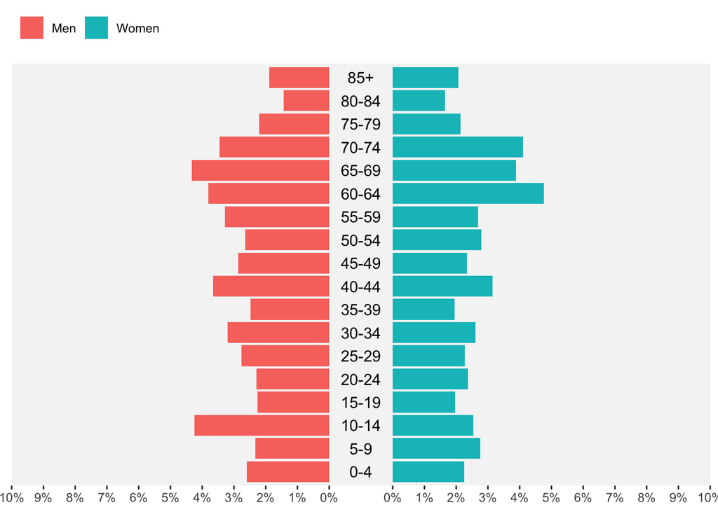

```r
oregon_population_pyramid_data %>%
  filter(county == "Baker") %>%
  ggplot() +
  aes(x = percent*100,
      y = fct_inorder(age),
      pyramid_cat = gender) +
  geom_rect(stat = StatPyramid,
            sep = 1) +
  aes(label = age)  +
  geom_text(stat = StatPyramidlabel) +
  scale_x_continuous(breaks = c(-10:0 - 1, 0:10 + 1),
                     labels = paste0(c(10:0, 0:10), "%"),
                     limits = c(-10,10)) +
  labs(y = NULL, x = NULL, fill = NULL) +
  theme(axis.text.y = element_blank(),
        axis.ticks.y = element_blank(),
        legend.position = "top",
        legend.justification = "left",
        panel.grid = element_blank(),
        panel.background = element_rect(fill = "whitesmoke")
        )
```

# Option 2. Use statexpress::stat_panel() to define user-facing functions

The statexpress package creates StatTemp in the background and wraps up the ‘scaffolding’ that is more typically used in defining user-facing functions. You won’t be able to use StatTemp itself.

## use statexpress to build functions

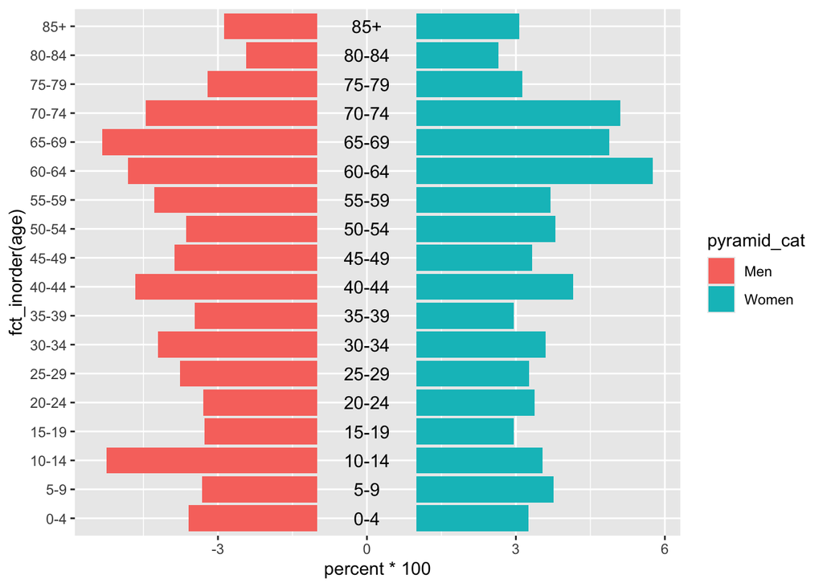

````r
compute_panel_pyramid <- function(data, scales, sep = 0, neg_cat = NULL){

  if(is.null(neg_cat)){neg_cat <- sort(data$pyramid_cat)[1] }

  data %>%
  mutate(split = ifelse(pyramid_cat == neg_cat, -sep, sep)) %>%
  mutate(xmin = 0 + split) %>%
  mutate(xmax = x * ifelse(pyramid_cat == neg_cat, -1, 1) + split) %>%
  mutate(y = as.numeric(as.factor(y))) %>%
  mutate(ymax = y + .45*1) %>%
  mutate(ymin = y - .45*1)

}

geom_split_pyramid <- function(...){
  statexpress::stat_panel(fun = compute_panel_pyramid,
                          geom = "rect",
                          default_aes = aes(fill = after_stat(pyramid_cat)),
                          ...
                          )}


compute_pyramid_label <- function(data, scales){

  data %>%
    distinct(y, label) %>%
    mutate(x = 0)

}

geom_split_pyramid_label <- function(...){
  statexpress::stat_panel(fun = compute_pyramid_label,
                          geom = "text",
                          ...)
}

# ```
#
#
# ## test them in plot
#
# ```{r or_pyramid2}
oregon_population_pyramid_data %>%
  filter(county == "Baker") %>%
  ggplot() +
  aes(x = percent*100,
      y = fct_inorder(age),
      pyramid_cat = gender) +
  geom_split_pyramid(sep = 1) +
  aes(label = age)  +
  geom_split_pyramid_label() ->
base; base
````

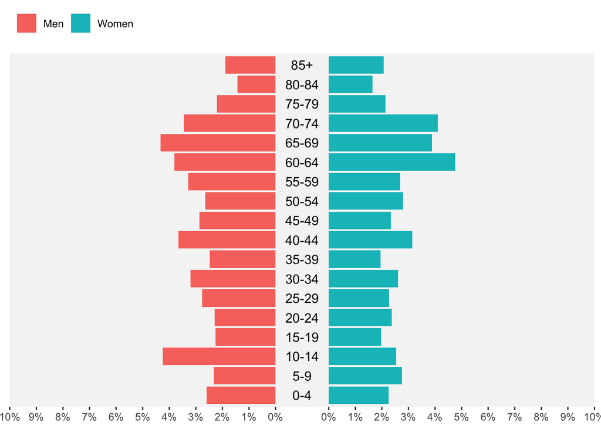

```r
# styling
base +
  scale_x_continuous(breaks = c(-10:0 - 1, 0:10 + 1),
                     labels = paste0(c(10:0, 0:10), "%"),
                     limits = c(-10,10)) +
  labs(y = NULL, x = NULL, fill = NULL) +
  theme(axis.text.y = element_blank(),
        axis.ticks.y = element_blank(),
        legend.position = "top",
        legend.justification = "left",
        panel.grid = element_blank(),
        panel.background = element_rect(fill = "whitesmoke")
        )
```

```r
layer_data(i = 2)
```

# To do, notes

- theme that complements pyramid
- scale shortcut (that complemnets outward shift)
- of course you can write something user-facing from geom_rect + StatPyramid. So a third step to get to what statexpress gets you in 2 steps.

# Much simpler examples of ‘express stats’

## Option 1. No dependency

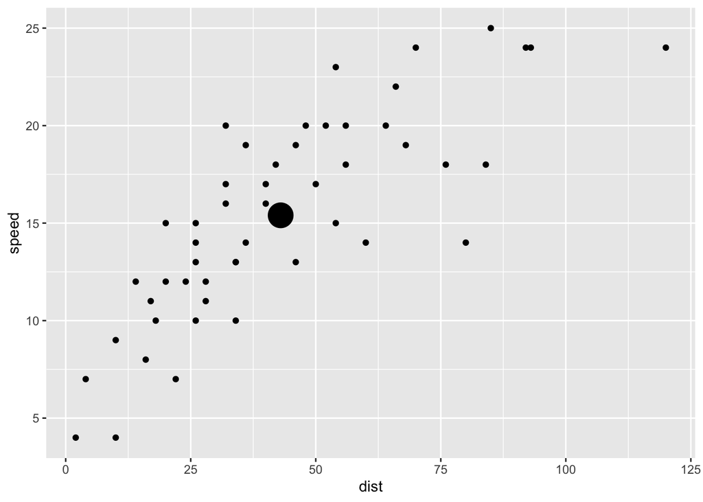

```r
library(ggplot2)
StatMeans <- ggproto("StatMeans",
                     Stat,
                     compute_group = function(data,scales){
                       x <- mean(data$x)
                       y <- mean(data$y)
                       data.frame(x,y)
                     })

ggplot(cars, aes(dist, speed)) +
  geom_point() +
  geom_point(stat = StatMeans, size = 8)
```

## Option 2. {statexpress}

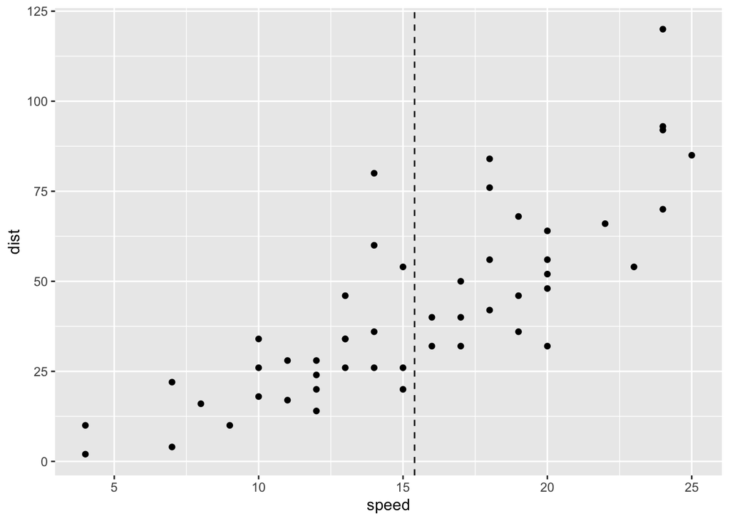

```r
library(tidyverse)

library(statexpress)
geom_xmean_line <- function(...){
  stat_group(function(df) df |>
               summarize(xintercept = mean(x)),
             "vline", dropped_aes = c("x", "y"), ...)}


ggplot(cars) +
  aes(speed, dist) +
  geom_point() +
  geom_xmean_line(linetype = 'dashed')
```

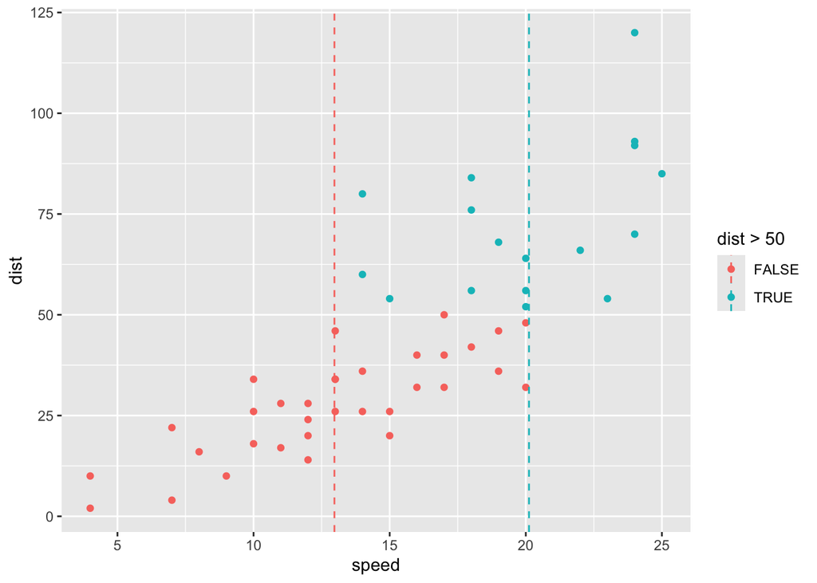

```r
last_plot() +
  aes(color = dist > 50)
```

## For reprex

```r
library(tidyverse)

oregon_population_pyramid_data <-
  read_csv("https://raw.githubusercontent.com/rfortherestofus/blog/main/population-pyramid-part-1/oregon_population_pyramid_data.csv")
compute_panel_pyramid <- function(data, scales, sep = 0, neg_cat = NULL){

  if(is.null(neg_cat)){neg_cat <- sort(data$pyramid_cat)[1] }

  data %>%
  mutate(split = ifelse(pyramid_cat == neg_cat, -sep, sep)) %>%
  mutate(xmin = 0 + split) %>%
  mutate(xmax = x * ifelse(pyramid_cat == neg_cat, -1, 1) + split) %>%
  mutate(y = as.numeric(as.factor(y))) %>%
  mutate(ymax = y + .45*1) %>%
  mutate(ymin = y - .45*1)

}

StatPyramid <- ggproto("StatPyramid",
                       Stat,
                       compute_panel = compute_panel_pyramid,
                       default_aes = aes(fill = after_stat(pyramid_cat)))


compute_pyramid_label <- function(data, scales){

  data %>%
    distinct(y, label) %>%
    mutate(x = 0)

}


StatPyramidlabel <- ggproto("StatPyramidlabel",
                            Stat,
                            compute_panel = compute_pyramid_label)


scale_x_pyramid <- function(sep = 1, breaks = 0:7, ...){

    scale_x_continuous(breaks = c(-rev(breaks) - sep, breaks + 1),
                     labels = paste0(c(rev(breaks), breaks), "%"),
                     limits = c(-max(breaks),max(breaks)), ...)

}


compute_panel_pyramid_no_cat <- function(data, scales, sep = 0, neg_cat = NULL){

  if(is.null(neg_cat)){neg_cat <- sort(data$pyramid_cat)[1] }

  data %>%
  mutate(x = mean(x), .by = y) %>%
  mutate(split = ifelse(pyramid_cat == neg_cat, -sep, sep)) %>%
  mutate(xmin = 0 + split) %>%
  mutate(xmax = x * ifelse(pyramid_cat == neg_cat, -1, 1) + split) %>%
  mutate(y = as.numeric(as.factor(y))) %>%
  mutate(ymax = y + .45*1) %>%
  mutate(ymin = y - .45*1)

}

StatPyramidequivilant <- ggproto("StatPyramidequivilant",
                                 Stat,
                                 compute_panel = compute_panel_pyramid_no_cat)


compute_panel_pyramid_minimum <- function(data, scales, sep = 0, neg_cat = NULL){

  if(is.null(neg_cat)){neg_cat <- sort(data$pyramid_cat)[1] }

  data %>%
  mutate(x = min(x), .by = y) %>%
  mutate(split = ifelse(pyramid_cat == neg_cat, -sep, sep)) %>%
  mutate(xmin = 0 + split) %>%
  mutate(xmax = x * ifelse(pyramid_cat == neg_cat, -1, 1) + split) %>%
  mutate(y = as.numeric(as.factor(y))) %>%
  mutate(ymax = y + .45*1) %>%
  mutate(ymin = y - .45*1)

}


StatPyramidequivilantminimum <- ggproto("StatPyramidequivilantminimum",
                                 Stat,
                                 compute_panel = compute_panel_pyramid_minimum)
```

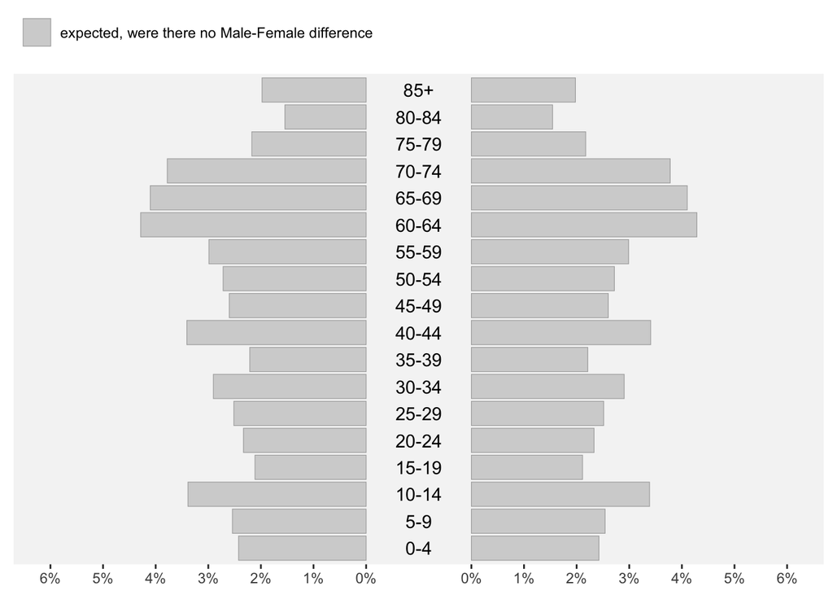

```r
oregon_population_pyramid_data %>%
  filter(county == "Baker") %>%
  ggplot() +
  aes(x = percent*100,
      y = fct_inorder(age),
      pyramid_cat = gender) +
  geom_rect(stat = StatPyramidequivilant, sep = 1,
            fill = "lightgrey",
            # linetype = "dotted",
            aes(color = "expected, were there no Male-Female difference"),
            linewidth = .2) +
  aes(label = age)  +
  geom_text(stat = StatPyramidlabel) +
  scale_x_pyramid() +
  labs(y = NULL, x = NULL, fill = NULL) +
  theme(axis.text.y = element_blank(),
        axis.ticks.y = element_blank(),
        legend.position = "top",
        legend.justification = "left",
        panel.grid = element_blank(),
        panel.background = element_rect(fill = "whitesmoke")
        ) +
  scale_color_manual(values = "darkgrey") +
  labs(color = NULL)
```

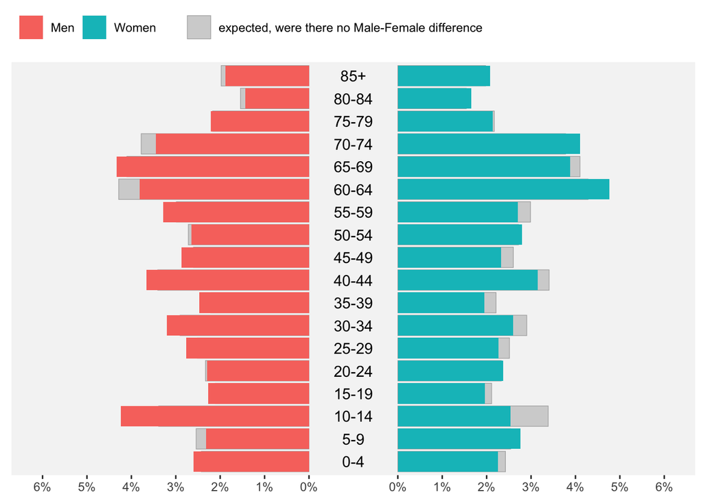

```r
last_plot() +
  geom_rect(stat = StatPyramid,
            sep = 1,
            linewidth = .2)
```

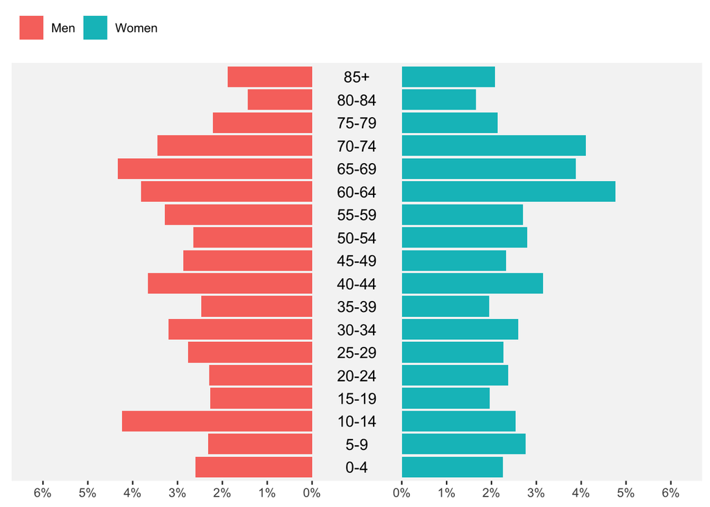

```r
oregon_population_pyramid_data %>%
  filter(county == "Baker") %>%
  ggplot() +
  aes(x = percent*100,
      y = fct_inorder(age),
      pyramid_cat = gender) +
  geom_rect(stat = StatPyramid, sep = 1,
            linewidth = .2) +
  aes(label = age)  +
  geom_text(stat = StatPyramidlabel) +
  scale_x_pyramid() +
  labs(y = NULL, x = NULL, fill = NULL) +
  theme(axis.text.y = element_blank(),
        axis.ticks.y = element_blank(),
        legend.position = "top",
        legend.justification = "left",
        panel.grid = element_blank(),
        panel.background = element_rect(fill = "whitesmoke")
        ) +
  scale_color_manual(values = "darkgrey") +
  labs(color = NULL)
```

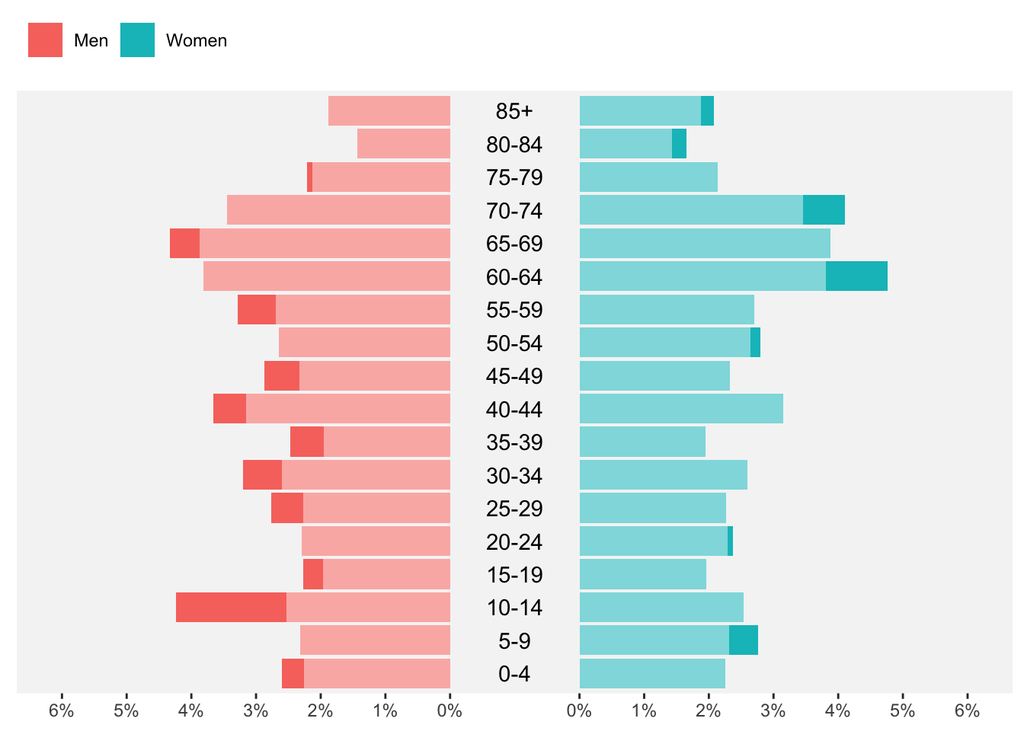

```r
last_plot() +
  geom_rect(stat = StatPyramidequivilantminimum, sep = 1,
            alpha = .45,
            fill = "white")
```